# examples for GwR chapter 2

Here’s some of the code from [Chapter 2: Geographic data in R](https://geocompr.robinlovelace.net/spatial-class.html), for you to follow along with as we go through it in class.

## Prerequisites

To speed things up, we’ll only install the binary versions of the packages:

```r
##options(pkgType = "binary")
##options(install.packages.check.source = "no")
```

These packages contain sample datasets, and need to be installed wherever you’re working:

```r
##install.packages("spData")
##install.packages("spDataLarge",
            ##     repos = "https://nowosad.r-universe.dev")
```

Load the packages:

```r
library(sf)
library(terra)
library(spData)
library(spDataLarge)
```

## Vector data

`sf` documentation:

```r
vignette(package = "sf")
vignette("sf1")
```

```
## starting httpd help server ... done
```

`world` dataset (from [spData](https://nowosad.github.io/spData/) package)

```r
world
```

```
## Simple feature collection with 177 features and 10 fields
## Geometry type: MULTIPOLYGON
## Dimension:     XY
## Bounding box:  xmin: -180 ymin: -89.9 xmax: 180 ymax: 83.64513
## Geodetic CRS:  WGS 84
## # A tibble: 177 × 11
##    iso_a2 name_long continent region_un subregion type  area_km2     pop lifeExp
##  * <chr>  <chr>     <chr>     <chr>     <chr>     <chr>    <dbl>   <dbl>   <dbl>
##  1 FJ     Fiji      Oceania   Oceania   Melanesia Sove…   1.93e4  8.86e5    70.0
##  2 TZ     Tanzania  Africa    Africa    Eastern … Sove…   9.33e5  5.22e7    64.2
##  3 EH     Western … Africa    Africa    Northern… Inde…   9.63e4 NA         NA
##  4 CA     Canada    North Am… Americas  Northern… Sove…   1.00e7  3.55e7    82.0
##  5 US     United S… North Am… Americas  Northern… Coun…   9.51e6  3.19e8    78.8
##  6 KZ     Kazakhst… Asia      Asia      Central … Sove…   2.73e6  1.73e7    71.6
##  7 UZ     Uzbekist… Asia      Asia      Central … Sove…   4.61e5  3.08e7    71.0
##  8 PG     Papua Ne… Oceania   Oceania   Melanesia Sove…   4.65e5  7.76e6    65.2
##  9 ID     Indonesia Asia      Asia      South-Ea… Sove…   1.82e6  2.55e8    68.9
## 10 AR     Argentina South Am… Americas  South Am… Sove…   2.78e6  4.30e7    76.3
## # … with 167 more rows, and 2 more variables: gdpPercap <dbl>,
## #   geom <MULTIPOLYGON [°]>
```

`sf` replaces the base `plot` function with one that understands simple features. The default output is a *faceted* plot: one facet per attribute, plotted on the same geometry:

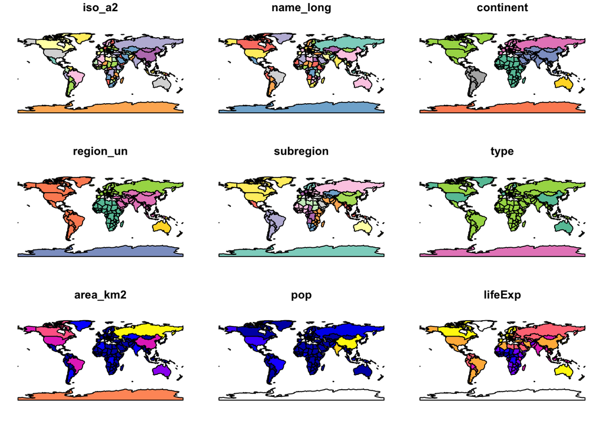

```r
plot(world)
```

Simple features are just data frames with geometry columns.

Generic data frame functions always retain the geometry column:

```r
summary(world["lifeExp"])
```

```
##     lifeExp                 geom
##  Min.   :50.62   MULTIPOLYGON :177
##  1st Qu.:64.96   epsg:4326    :  0
##  Median :72.87   +proj=long...:  0
##  Mean   :70.85
##  3rd Qu.:76.78
##  Max.   :83.59
##  NA's   :10
```

The contents of the geometry column are opaque:

```r
world["geom"]
```

```
## Simple feature collection with 177 features and 0 fields
## Geometry type: MULTIPOLYGON
## Dimension:     XY
## Bounding box:  xmin: -180 ymin: -89.9 xmax: 180 ymax: 83.64513
## Geodetic CRS:  WGS 84
## # A tibble: 177 × 1
##                                                                             geom
##                                                               <MULTIPOLYGON [°]>
##  1 (((-180 -16.55522, -179.9174 -16.50178, -179.7933 -16.02088, -180 -16.06713,…
##  2 (((33.90371 -0.95, 31.86617 -1.02736, 30.76986 -1.01455, 30.4191 -1.134659, …
##  3 (((-8.66559 27.65643, -8.817828 27.65643, -8.794884 27.1207, -9.413037 27.08…
##  4 (((-132.71 54.04001, -133.18 54.16998, -133.2397 53.85108, -133.0546 53.4114…
##  5 (((-171.7317 63.78252, -171.7911 63.40585, -171.5531 63.31779, -170.6714 63.…
##  6 (((87.35997 49.21498, 86.82936 49.82667, 85.54127 49.69286, 85.11556 50.1173…
##  7 (((55.96819 41.30864, 57.09639 41.32231, 56.93222 41.82603, 57.78653 42.1705…
##  8 (((141.0002 -2.600151, 141.0171 -5.859022, 141.0339 -9.117893, 142.0683 -9.1…
##  9 (((104.37 -1.084843, 104.0108 -1.059212, 103.4376 -0.7119459, 103.8384 0.104…
## 10 (((-68.63401 -52.63637, -68.63335 -54.8695, -67.56244 -54.87001, -66.95992 -…
## # … with 167 more rows
```

But you can convert them individually to “well-known text” (WKT) format. (Note the use of [[ ]], since we want a single value, not a list or a tibble.)

```r
st_as_text(world[[1,"geom"]])
```

```
## [1] "MULTIPOLYGON (((-180 -16.55522, -179.9174 -16.50178, -179.7933 -16.02088, -180 -16.06713, -180 -16.55522)), ((178.1256 -17.50481, 177.6709 -17.38114, 177.285 -17.72465, 177.3815 -18.16432, 177.9327 -18.28799, 178.5527 -18.15059, 178.7181 -17.62846, 178.3736 -17.33992, 178.1256 -17.50481)), (…
```

`plot` is useful for quickly exploring the results of spatial operations.

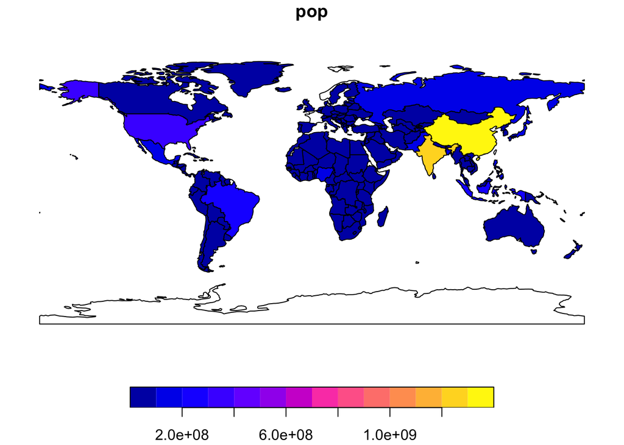

```r
plot(world["pop"])
```

Extract the countries in Asia from the `world` dataset:

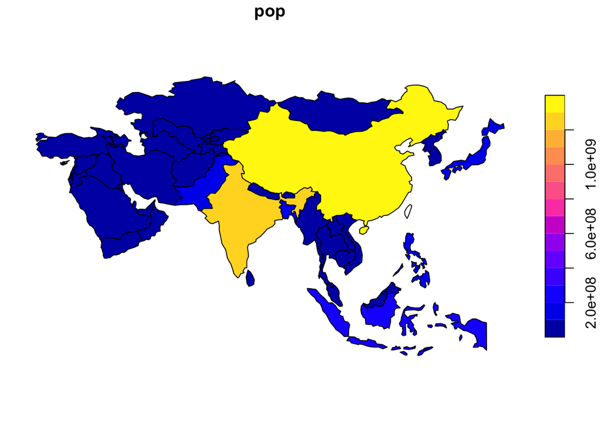

```r
world_asia = world[world[["continent"]] == "Asia", ]
plot(world_asia["pop"])
```

Merge all of the countries in Asia into a single geometry:

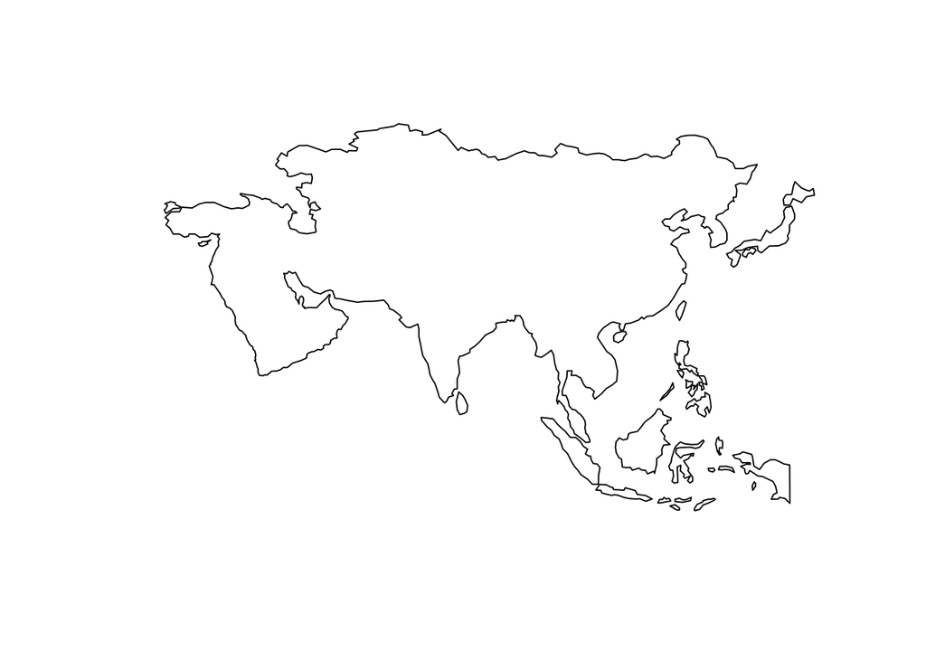

```r
asia = st_union(world_asia)
plot(asia)
```

Of course, when you do that, you lose all of the attributes of the individual countries:

```r
names(world_asia)
```

```
##  [1] "iso_a2"    "name_long" "continent" "region_un" "subregion" "type"
##  [7] "area_km2"  "pop"       "lifeExp"   "gdpPercap" "geom"
```

```r
names(asia)
```

[output not shown]

Layer the Asia outline on top of a map of world population:

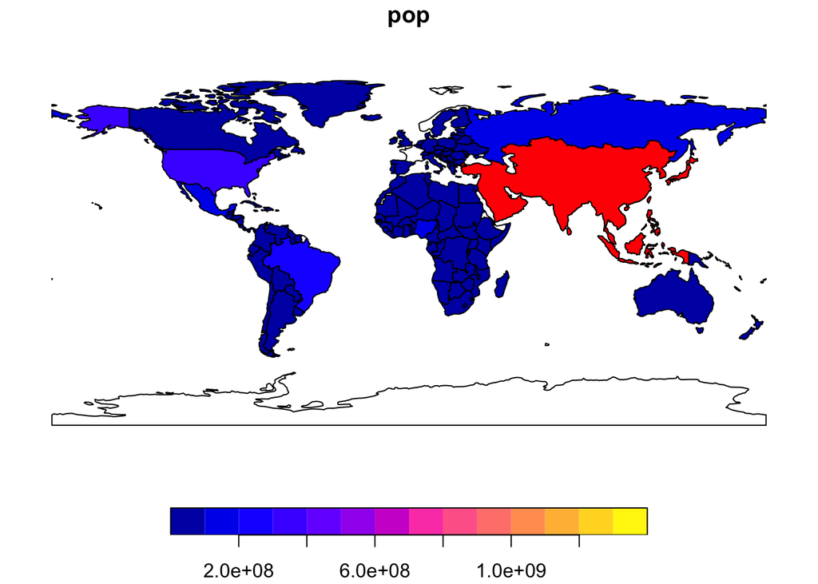

```r
plot(world["pop"], reset = FALSE)
plot(asia, add = TRUE, col = "red")
```

```r
# instead of col, try border and lwd
```

Add symbols to a map.

(Why is this map lame?)

```r
world_centroids = st_centroid(world, of_largest_polygon = TRUE)
```

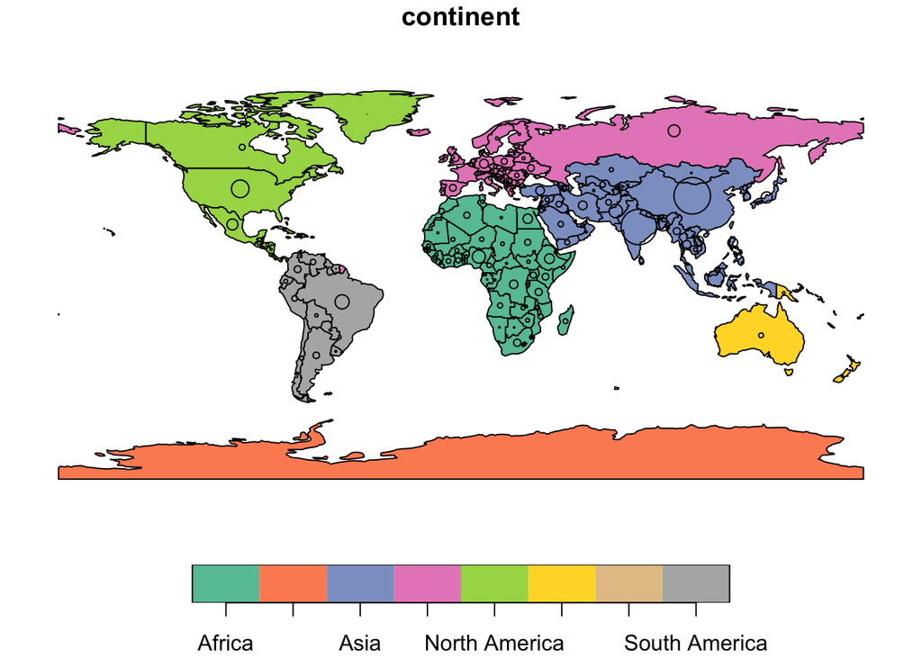

```r
symbol_size = sqrt(world[["pop"]]) / 10000

plot(world["continent"], reset = FALSE)
plot(st_geometry(world_centroids), add = TRUE, cex = symbol_size)
```

Geometry types:

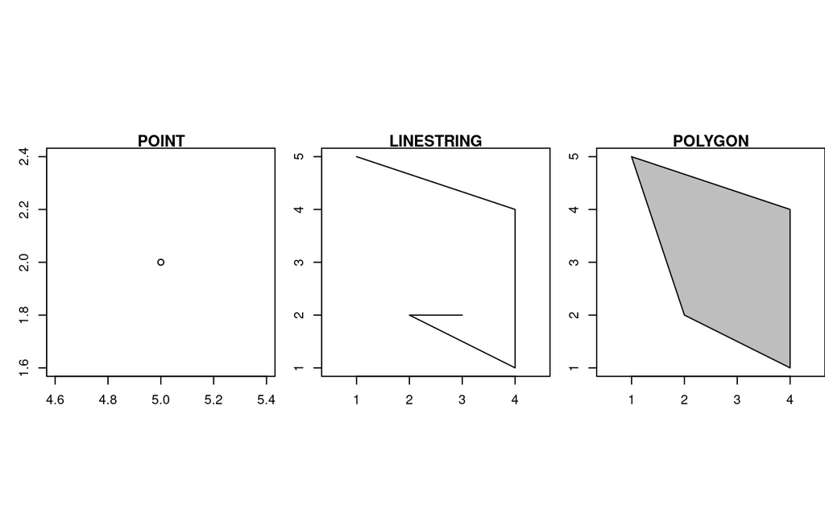

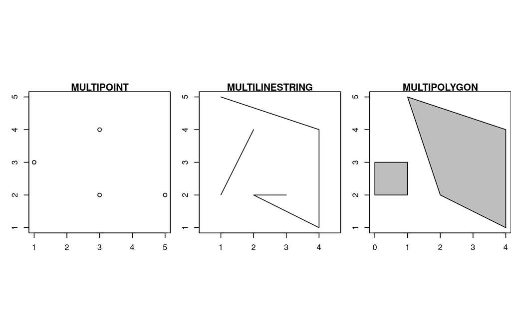

Assembling a geometry (polygon example)

```r
c(1,5)
```

```
## [1] 1 5
```

```r
rbind(c(1, 5), c(2, 2), c(4, 1), c(4, 4), c(1, 5))
```

```
##      [,1] [,2]
## [1,]    1    5
## [2,]    2    2
## [3,]    4    1
## [4,]    4    4
## [5,]    1    5
```

```r
list(rbind(c(1, 5), c(2, 2), c(4, 1), c(4, 4), c(1, 5)))
```

```
## [[1]]
##      [,1] [,2]
## [1,]    1    5
## [2,]    2    2
## [3,]    4    1
## [4,]    4    4
## [5,]    1    5
```

```r
polygon = st_polygon(list(rbind(c(1, 5), c(2, 2), c(4, 1), c(4, 4), c(1, 5))))
polygon
```

```
## POLYGON ((1 5, 2 2, 4 1, 4 4, 1 5))
```

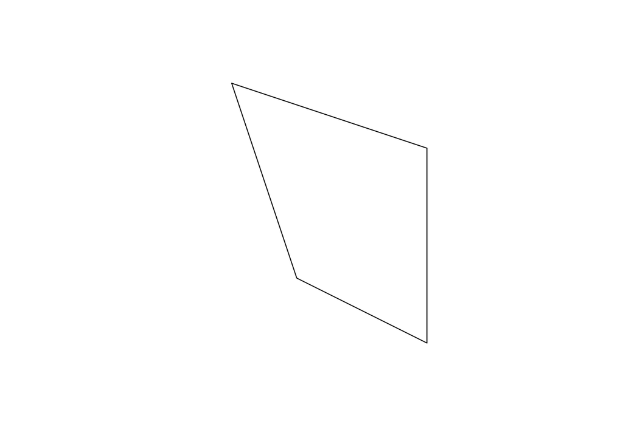

```r
plot(polygon)
```

```r
st_as_text(st_polygon(list(rbind(c(1, 5), c(2, 2), c(4, 1), c(4, 4), c(1, 5)))))
```

```
## [1] "POLYGON ((1 5, 2 2, 4 1, 4 4, 1 5))"
```